# Introducción a Python 3 para Ciencia de Datos

## Contenidos

- 3. NumPy: trabajando con datos numéricos
  - 3.1 Creación de arrays
  - 3.2 Indexación de arrays
- 4. Visualización de datos básica
  - 4.1 Matplotlib
  - 4.2 Seaborn
  - 4.3 Bokeh

## Otros recursos

# 3. NumPy: trabajando con datos numéricos

Aunque Python nos proporciona soporte para trabajar con tipos de datos numéricos básicos, existe una alternativa mejor para realizar cálculos computacionales de forma más eficiente. La biblioteca NumPy proporciona soporte de alto rendimiento específico para datos numéricos, en particular para arrays (vectores y matrices).

La **condición** más importante que deben cumplir los arrays definidos con NumPy es que deben **ser homogéneos**, es decir, almacenan colecciones multidimensionales de elementos del mismo tipo. Los **tipos soportados** suelen ser numéricos (integer, float) pero también pueden ser objetos Python.

Para empezar a utilizar la biblioteca NumPy solo tenemos que importarla en nuestro programa. La conenvción que se suele usar es la de abreviar su nombre por `np`.

```python
import numpy as np
```

## 3.1 Creación de arrays

```python
# Directamente, a través de objetos de tipo secuencia
# El orden importa, ya que determina las dimensiones que
# tendrá nuestro array

array1 = np.array(((1, 2, 3), (4, 5, 6), (7, 8, 9)))
array2 = np.array(((1, 1, 1), (2, 2, 2), (3, 3, 3)))
array3 = np.array([[[1., 2.], [3., 4.]], [[5., 6.], [7., 8.]]])

print(array1.dtype)
print(array3.dtype)

print(len(array1))
print(len(array3))

print(array1.shape)
print(array3.shape)

# Funciones para crear arrays automáticamente
arr = np.arange(8)
arr2 = np.arange(1, 10, 3)

arr3 = np.linspace(0, 2*np.pi, 50) # Inicioi, fin, núm. puntos
print(arr3)

# Arrays comunes predefinidos
unos = np.ones((3,2))
ceros = np.zeros((1,2))
ident = np.eye(4)
diag = np.diag(np.array((1, 2, 3, 4, 5)))
diag
```

```
int64
float64
3
2
(3, 3)
(2, 2, 2)
[ 0.          0.12822827  0.25645654  0.38468481  0.51291309  0.64114136
  0.76936963  0.8975979   1.02582617  1.15405444  1.28228272  1.41051099
  1.53873926  1.66696753  1.7951958   1.92342407  2.05165235  2.17988062
  2.30810889  2.43633716  2.56456543  2.6927937   2.82102197  2.94925025
  3.07747852  3.20570679  3.33393506  3.46216333  3.5903916   3.71861988
  3.84684815  3.97507642  4.10330469  4.23153296  4.35976123  4.48798951
  4.61621778  4.74444605  4.87267432  5.00090259  5.12913086  5.25735913
  5.38558741  5.51381568  5.64204395  5.77027222  5.89850049  6.02672876
  6.15495704  6.28318531]
```

```
array([[1, 0, 0, 0, 0],
       [0, 2, 0, 0, 0],
       [0, 0, 3, 0, 0],
       [0, 0, 0, 4, 0],
       [0, 0, 0, 0, 5]])
```

## 3.2 Indexación de arrays

```python
# Diferentes formas de indexación de arrays

# Elementos por ubicación
print(array1[1, 1], array1[-1, -2])

# Slicing
print(array2[1:3, 1:3])

# Elementos en orden inverso
print(diag[::-1])
```

```
5 8
[[2 2]
 [3 3]]
[[0 0 0 0 5]
 [0 0 0 4 0]
 [0 0 3 0 0]
 [0 2 0 0 0]
 [1 0 0 0 0]]
```

Se recomienda estudiar bien los ejemplos incluidos en [SciPy-Lectures](http://www.scipy-lectures.org/intro/numpy/array_object.html#indexing-and-slicing).

## 3.3 Operaciones sobre arrays

```python
# Multiplicación de arrays y matrices

# Producto de dos arrays (elemento a elemento)
a = np.array([[1, 2, 3, 4]])
b = np.array([[1, 2, 3, 4]])

print(a * b)

# Producto de dos arrays bi-dimensionales
print (array1 * array2)

# Cuidado: Si queremos producto de matrices, hay que definirlas
# como tales
mat1 = np.matrix( ((1,2,3), (1,2,3), (1,2,3)) )
mat2 = np.matrix( ((1,2,3), (1,2,3), (1,2,3)) )
print('Multiplicación de matrices:')
print(mat1 * mat2)

# Cambios de dimensiones
array = np.array(( (1, 2, 3),
                   (4, 5, 6),
                   (7, 8, 9),
                   (10, 11, 12) ))
print(array)
# Pasamos array a una sola dimensión
print('Array en 1-D (ravel):')
print(array.ravel())
# Pero el array original no se modifica
print(array)
# Redimensionamos el array
print('Array resize():')
array.resize((3,4))
# Ahora, el original se ha modificado
print(array)
# Cambiamos de nuevo las dimensiones del array
print('Array reshape():')
print(array.reshape(4,3))
# Pero en este caso el array original no se modifica
print(array)

# Máscaras de selección
array2 = np.ma.masked_array(array, mask=array > 3)
print(array2)
```

```
[[ 1  4  9 16]]
[[ 1  2  3]
 [ 8 10 12]
 [21 24 27]]
Multiplicación de matrices:
[[ 6 12 18]
 [ 6 12 18]
 [ 6 12 18]]
[[ 1  2  3]
 [ 4  5  6]
 [ 7  8  9]
 [10 11 12]]
Array en 1-D (ravel):
[ 1  2  3  4  5  6  7  8  9 10 11 12]
[[ 1  2  3]
 [ 4  5  6]
 [ 7  8  9]
 [10 11 12]]
Array resize():
[[ 1  2  3  4]
 [ 5  6  7  8]
 [ 9 10 11 12]]
Array reshape():
[[ 1  2  3]
 [ 4  5  6]
 [ 7  8  9]
 [10 11 12]]
[[ 1  2  3  4]
 [ 5  6  7  8]
 [ 9 10 11 12]]
[[1 2 3 --]
 [-- -- -- --]
 [-- -- -- --]]
```

# 4. Visualización de datos básica

Existen varias alternativas para visualizar nuestros datos en Python. Aquí, introducimos brevemente 3 opciones muy populares: [Matplotlib](http://matplotlib.org/), [Seaborn](http://stanford.edu/~mwaskom/software/seaborn/) y [Bokeh](http://bokeh.pydata.org/en/latest/).

## 4.1 Matplotlib

La biblioteca `Matplotlib` suele ser la solución más sencilla y extendida para representación gráfica de datos en Python.

A continuación, presentamos un ejemplo sencillo para mostrar algunas de sus posibilidades. Se pueden consultar diferentes tutoriales para ampliar información:

- [Documentación en línea de Matplotlib](http://matplotlib.org/users/index.html).
- [Tutorial en SciPy Lecture Notes sobre Matplotlib](http://www.scipy-lectures.org/intro/matplotlib/matplotlib.html).

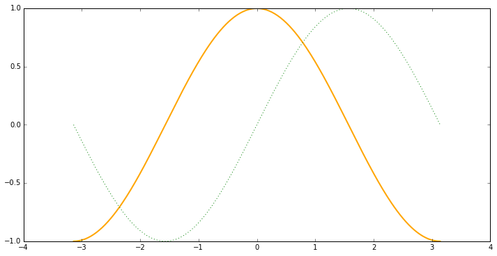

```python
# Debemos importar la biblioteca
from matplotlib import pyplot as plt
# Y configurarla para que muestre
# los gráficos integrados en nuestro documento
%matplotlib inline


# Creamos figura de 12x6 pulgadas, resolución de 100ppp
plt.figure(figsize=(12, 6), dpi=100)

# X serán 256 puntos equiespaciados entre -pi y pi
x = np.linspace(-np.pi, np.pi, 256, endpoint=True)
# Y serán las funciones sin(x) y cos(x)
y_cos, y_sen = np.cos(x), np.sin(x)

# Pintamos el coseno en naranja, con grosor de línea 2 píxeles,
# estilo de linea estándar
plt.plot(x, y_cos, color="orange", linewidth=2, linestyle="-")

# Pintamos el seno en verde, grosor de línea 1 píxel, línea punteada
plt.plot(x, y_sen, color="green", linewidth=1.0, linestyle=":")

# Límites del eje x en el gráfico
plt.xlim(-4.0, 4.0)

# Cómo se muestran marcas en los ejes
plt.xticks(np.linspace(-4, 4, 9, endpoint=True))

# Igual para el eje de ordenadas
plt.ylim(-1.0, 1.0)
plt.yticks(np.linspace(-1, 1, 5, endpoint=True))

# Se puede guardar la figura en un archivo, con otra resolución
# plt.savefig("ejemplo_1.png", dpi=80)

# Mostrar la figura en pantalla
plt.show()
```

## 4.2 Seaborn

Es otra biblioteca de representación gráfica en Python. Viene incluida en *Anaconda*, así que solo tenemos que importarla para empezar a trabajar con ella.

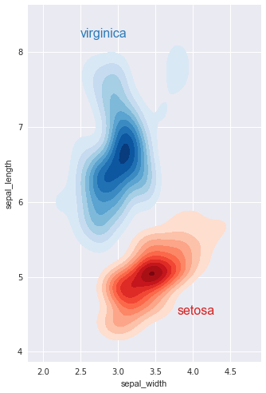

```python
# Importamos la biblioteca
import seaborn as sns

# Creamos un pequeño ejemplo para ver la diferencia
sns.set(style="darkgrid")
iris = sns.load_dataset("iris")

# Subset the iris dataset by species
setosa = iris.query("species == 'setosa'")
virginica = iris.query("species == 'virginica'")

# Set up the figure
f, ax = plt.subplots(figsize=(8, 8))
ax.set_aspect("equal")

# Draw the two density plots
ax = sns.kdeplot(setosa.sepal_width, setosa.sepal_length,
                 cmap="Reds", shade=True, shade_lowest=False)
ax = sns.kdeplot(virginica.sepal_width, virginica.sepal_length,
                 cmap="Blues", shade=True, shade_lowest=False)

# Add labels to the plot
red = sns.color_palette("Reds")[-2]
blue = sns.color_palette("Blues")[-2]
ax.text(2.5, 8.2, "virginica", size=16, color=blue)
ax.text(3.8, 4.5, "setosa", size=16, color=red)
```

## 4.3 Bokeh

```python
import numpy as np
from bokeh.plotting import figure, show
from bokeh.io import output_notebook

# prepare some data
N = 4000
x = np.random.random(size=N) * 100
y = np.random.random(size=N) * 100
radii = np.random.random(size=N) * 1.5
colors = ["#%02x%02x%02x" % (int(r), int(g), 150) for r, g in zip(np.floor(50+2*x), np.floor(30+2*y))]

# Configurar para que muestre las figuras en el notebook
output_notebook()
```

BokehJS successfully loaded.

```python
TOOLS="resize,crosshair,pan,wheel_zoom,box_zoom,reset,box_select,lasso_select"

# create a new plot with the tools above, and explicit ranges
p = figure(tools=TOOLS, x_range=(0,100), y_range=(0,100))

# add a circle renderer with vecorized colors and sizes
p.circle(x,y, radius=radii, fill_color=colors, fill_alpha=0.6, line_color=None)

# show the results
show(p)
```

[output not shown]